# Analysis of Corpus text data to build a predictive texting solution

Sayef Ishauqe

December 30, 2017

## Synopsis

This document presents a proposal for developing a predictive texting solution using R and Shiny App. Primarily, it will download and analyze text files to explore its content with for interesting patterns, ideas and challenges to develop predictive texting.

## Download The Data

```r
fileURL<-"https://d396qusza40orc.cloudfront.net/dsscapstone/dataset/Coursera-SwiftKey.zip"
inputFile<-"data/SwiftKey.zip"
en_tw_path<-"data/final/en_US/en_US.twitter.txt"

## check whether the file is already downloaded in project folder

if(!file.exists(en_tw_path))
{
     ## Downloading file
     download.file(fileURL,inputFile,"curl")

     ## Unziping file in data directory
     unzippedFile<-"data/."
     unzip(inputFile,exdir=unzippedFile)
}
```

## Analyze the content of input files

The downloaded files contain texts in multiple langulages. The following code analyzes content of engish language files.

```r
base_path<-"data/final/en_US/"
filepaths<-paste0(base_path,dir(base_path))

con<-lapply(filepaths,file,open="r")
lines<-lapply(con,readLines,encoding="UTF-8",skipNul=TRUE)
a<-lapply(con,close)

line_length<-lapply(lines,nchar)
no_of_chars<-lapply(line_length,sum)
no_of_lines<-lapply(line_length,length)
max_line_length<-lapply(line_length,max)
file_size<-lapply(lapply(lines, object.size),format,units="MB")

result_df<-data.frame()
result_df<-cbind(file_names=dir(base_path),no_of_lines,max_line_length,file_size)
result_df
```

```
##      file_names          no_of_lines max_line_length file_size
## [1,] "en_US.blogs.txt"   899288      40833           "248.5 Mb"
## [2,] "en_US.news.txt"    77259       5760            "19.2 Mb"
## [3,] "en_US.twitter.txt" 2360148     140             "301.4 Mb"
```

It is evident that there are differences in text content from 3 different sources. Also, the size of these files are too large to be analyzed further. So, there needs to ba a mechanism to sample the files.

## Take equal sample of files

```r
sample_no_of_lines_per_file<-round(sum(as.numeric(no_of_lines))*.05/3,0)
# total_size<-object.size(lines)
# file_size<-as.numeric(lapply(lines,object.size))
# file_size_proportion<-file_size/total_size

set.seed(35546)

getLineSample <- function(x,size) {
     sample(x,size)
}

linesSample<-lapply(lines,getLineSample,sample_no_of_lines_per_file)

sample_size<- format(object.size(linesSample),units="MB")
```

The above sampling technique takes 55612 lines from each file and creates sample text of size 36.4 Mb.

## Pre-processing of sample data

At first, the punctuation and non-printable characters has to be removed as those can cause the script to terminate abruptly. Once, this is done, more sophiscticated clean-up can be done using pre-built packages.

```r
library(tm)
mygsub <- function(x,p,r) {

     #wrapper function for easy gsub usage in lapply
     gsub(p,r,x)
}
linesClean<-lapply(linesSample,mygsub,"^(https?:\\/\\/)?([\\da-z\\.-]+)\\.([a-z\\.]{2,6})([\\/\\w \\.-]*)*\\/?$"," ")
linesClean<-lapply(linesClean,mygsub,"\\?\\!",".")
linesClean<-lapply(linesClean,mygsub,"[^[:print:][:punct:]]"," ")


docs<-VCorpus(VectorSource(linesClean))

docs <- tm_map(docs, removeNumbers)
#remove stopwords using the standard list in tm
docs <- tm_map(docs, removeWords, stopwords("english"))
docs <- tm_map(docs, removePunctuation)
docs <- tm_map(docs, stemDocument, language = c("english"), lazy = TRUE)
```

## Analyze frequent words

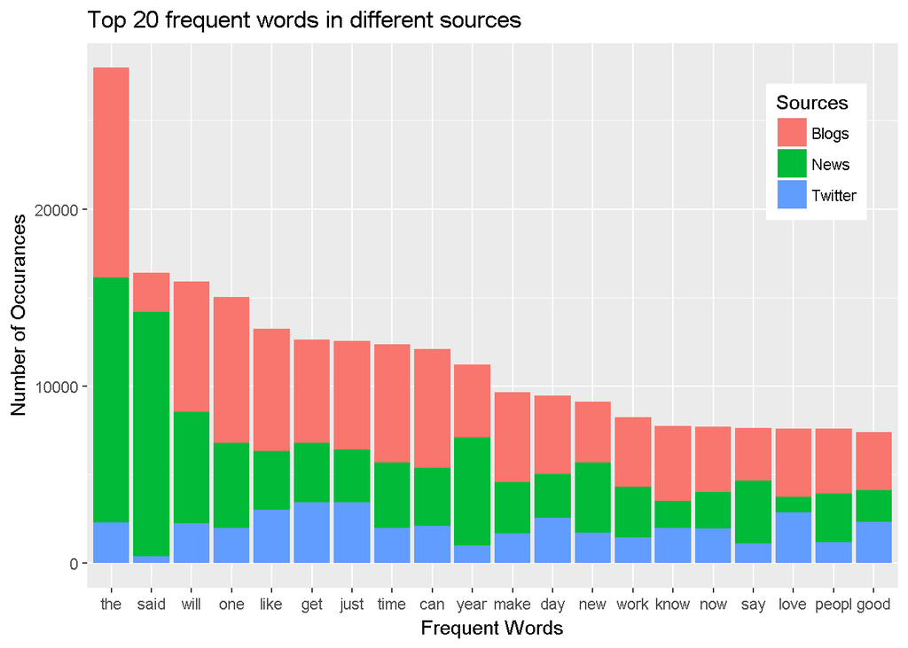

The above chart identifies frequently used words in the sample text. It is evident that the frequencies varies by type of sources. For example, the word the is very frequent but not so in twitter as users are required to write twitts within 140 characters.

## Analyze n-gram

A n-gram analysis will provide further insight on predictive texting. However, executing n-gram algorithms can be resource hungry. So, as a preliminary analysis a 2-gram analysis will be executed.

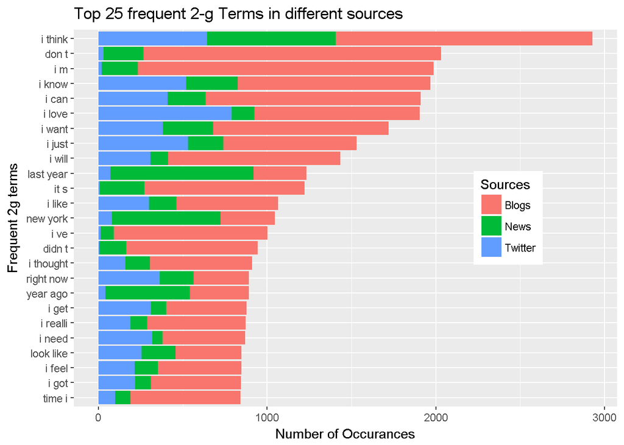

## Conclusion and Next steps

At this point, it is evident that the approach taken to develop a list of frequent terms and 2-g terms can be followed to prepare a predictive texting solution.

- The pre-processing and sampling apprach taken works to analyze freqent words and 2-g terms. For sample size 36.4 Mb, it took 3.06 mins to generate frequent terms and 1.33 mins for 2-g terms respectively.
- Number of frequent and 2-g terms identified could be used to develop the predictive texting solution. For instance, number of 2-g terms which had more that 1 occurance were 308923. This could be stored in a file and searched on while users are typing to provide predictive answers.

### Next steps

- Develop a strategy to handle miss-spelled words
- Check if 3-gram and/or 4-gram terms can be identified similarly for predictive texting
- Develop a solution to store the n-grams and frequent terms in a file(s) for future use
- Check whether developing different terms/n-grams for blogging, twitting makes better sense
- Evaluate the approach in terms of memory requirements
- Develop a shiny app based on the above analysis and steps